# A summary on labour market power literature

Seiro Ito

2023年12月01日 10:13

(労働市場力研究に関する要約)

Seiro Ito

**Abstract** I summarize the various proposed methods of production approach to markups/markdowns/TFP estimation. I make distrinctions between FOCs of profit maximization and FOCs of cost minimization. The original method of Hall (1998) only uses cost minimization, so do De Loecker and Warzynski (2012). Once factor price markdown is considered, one needs the marginal revenue product of an input so it takes profit maximization FOC. GNR (2020) consider output price markups yet use profit maximization FOC, which can be their limitation.

# Summary

- Generally speaking, concentration may be a misleading measure of market power.
- Monopolistic competition of heterogenous firms can result in a negative relationship between market power and concentration.
- A more solid definition of market power is given by output price markups (downstream) or input price markdowns (upstream).
- But using concentration can be OK in some markets: Studies on US/online labour markets show concentration is positively related to markdowns/supression of wages.
- So one can start with concentration, then proceed to wage markdowns.
- Many studies estimate markups/markdowns at the establishment level with financial statement data using the “production approach”.
- It only assumes cost minimization of firms.
- Production approach looked very useful, but the criticism of nonidentification results by Gandhi, Navarro, and Rivers (2020).

  Gandhi, Amit, Salvador Navarro, and David A. Rivers. 2020. “On the Identification of Gross Output Production Functions.” *Journal of Political Economy* 128 (8): 2973–3016. https://doi.org/10.1086/707736.
- Literature has not come up with a method that responds to the criticism.
- For the time being, one can start with the Rubens’ or DJ’s method to estimate wage markdowns.

# Introduction

Following Hall (1988)’s industry level estimation, De Loecker and Warzynski (2012) developed the “production approach” to TFPR/markup estimation at the plant/firm level, by using only financial statement of firms.

Hall, Robert E. 1988. “The Relation Between Price and Marginal Cost in US Industry.” *Journal of Political Economy* 96 (5): 921–47.

De Loecker, Jan, and Frederic Warzynski. 2012. “Markups and Firm-Level Export Status.” *American Economic Review* 102 (6): 2437–71. https://doi.org/10.1257/aer.102.6.2437.

Their algorithm follows the tradition of inverting a factor demand function to obtain (to “proxy”) productivity $\omega_{jt}$ (Olley and Pakes 1996; Levinsohn and Petrin 2003; synthesized by Ackerberg, Caves, and Frazer 2015).

Olley, G. Steven, and Ariel Pakes. 1996. “The Dynamics of Productivity in the Telecommunications Equipment Industry.” *Econometrica* 64 (6): 1263–97.

Levinsohn, James, and Amil Petrin. 2003. “Estimating Production Functions Using Inputs to Control for Unobservables.” *Review of Economic Studies* 70 (2): 317–41.

Ackerberg, Daniel A., Kevin Caves, and Garth Frazer. 2015. “Identification Properties of Recent Production Function Estimators.” *Econometrica* 83 (6): 2411–51. https://doi.org/10.3982/ECTA13408.

There are debates over ACF-DLW method:

- Invertibility of factor demand, aka scalar unobservable ass. and monotinicity ass. (Bond et al. 2021; but see Appendix O.6.3 of Yeh, Macaluso, and Hershbein 2022; while Demirer 2022 allows labour augmenting shocks in addition to Hicks neutral shocks under the homothetic production function)

  Bond, Steve, Arshia Hashemi, Greg Kaplan, and Piotr Zoch. 2021. “Some Unpleasant Markup Arithmetic: Production Function Elasticities and Their Estimation from Production Data.” *Journal of Monetary Economics* 121: 1–14. https://doi.org/10.1016/j.jmoneco.2021.05.004.

  Yeh, Chen, Claudia Macaluso, and Brad Hershbein. 2022. “Monopsony in the US Labor Market.” *American Economic Review* 112 (7): 2099–2138. https://doi.org/10.1257/aer.20200025.

  Demirer, Mert. 2022. “Production Function Estimation with Factor-Augmenting Technology: An Application to Markups.” https://demirermert.github.io/Papers/Demirer_production_function%202.pdf.
- Nonidentification results when one uses profit maximization FOC on a flexible input (materials, energey) in a gross output production function (Gandhi, Navarro, and Rivers 2020).

  Gandhi, Amit, Salvador Navarro, and David A. Rivers. 2020. “On the Identification of Gross Output Production Functions.” *Journal of Political Economy* 128 (8): 2973–3016. https://doi.org/10.1086/707736.
- Nonidentification results when using deflated revenues in place of physcal quantity and profit maximation FOC (Bond et al. 2021; see also a reply by De Loecker 2021 of practices of controlling output prices and also input prices).

  Bond, Steve, Arshia Hashemi, Greg Kaplan, and Piotr Zoch. 2021. “Some Unpleasant Markup Arithmetic: Production Function Elasticities and Their Estimation from Production Data.” *Journal of Monetary Economics* 121: 1–14. https://doi.org/10.1016/j.jmoneco.2021.05.004.

  De Loecker, Jan. 2021. “Comment on (Un)pleasant ... By Bond Et Al (2020).” *Journal of Monetary Economics* 121: 15–18. https://doi.org/10.1016/j.jmoneco.2021.04.009.
- Endogeneity of inputs (or what the valid IVs are, Doraszelski and Jaumandreu 2021)

  Doraszelski, Ulrich, and Jordi Jaumandreu. 2021. “Reexamining the de Loecker & Warzynski (2012) Method for Estimating Markups.”
- Hicks neutral (factor non-augmenting) tech assumption (Doraszelski and Jaumandreu 2013; Demirer 2022; Raval 2023)

  Doraszelski, Ulrich, and Jordi Jaumandreu. 2013. “R& D and productivity: Estimating endogenous productivity.” *The Review of Economic Studies* 80 (4): 1338–83. https://doi.org/10.1093/restud/rdt011.

  Demirer, Mert. 2022. “Production Function Estimation with Factor-Augmenting Technology: An Application to Markups.” https://demirermert.github.io/Papers/Demirer_production_function%202.pdf.

  Raval, Devesh. 2023. “Testing the production approach to markup estimation.” *The Review of Economic Studies* 90 (5): 2592–2611. https://doi.org/10.1093/restud/rdad002.

# Market power and concentration measures

Originally, below is the problem.

Output market power $:=$ Markup, or the difference between price and marginal cost.

Input market power $:=$ Markdown, or the difference between factor price and marginal revenue product.

Problem: We do not observe marginal X.

## Old method: Structure-conduct-performance literature

Herfindahl-Hirschman index (HHI, a summary measure of market shares) was used as a proxy in the IO literature up to 1980’s. The practice is used outside the IO even now.

Problem: Monopolistically competitive models with heterogenous firms can predict: concentration$\uparrow$ $\sim$ markup$\downarrow$

[interactive chart not shown]

## Current method

More recently, one uses markups (and markdowns) by obtaining marginal “X” in some way.

Despite concerns, the old method may be valid in some markets. A positive relationship between market power and concentration:

- Employment share and markdowns (Yeh, Macaluso, and Hershbein 2022)
- Employment effects of minimum wages (if small, originally large markdown) and HHI (Azar et al. 2019)

  Azar, José, Emiliano Huet-Vaughn, Ioana Marinescu, Bledi Taska, and Till Von Wachter. 2019. “Minimum Wage Employment Effects and Labor Market Concentration.” *NBER Working Paper Series*. Vol. 26101. National Bureau of Economic Research. https://www.nber.org/system/files/working_papers/w26101/w26101.pdf.
- Job application elasticity (if small, large power) and HHI (Azar, Marinescu, and Steinbaum 2019)

  Azar, José, Ioana Marinescu, and Marshall Steinbaum. 2019. “Measuring Labor Market Power Two Ways.” *AEA Papers and Proceedings* 109 (May): 317–21. https://doi.org/10.1257/pandp.20191068.
- Earnings or wages (low) and HHI (Azar et al. 2020; Benmelech, Bergman, and Kim 2022)

  Azar, José, Ioana Marinescu, Marshall Steinbaum, and Bledi Taska. 2020. “Concentration in US Labor Markets: Evidence from Online Vacancy Data.” *Labour Economics* 66: 101886. https://doi.org/10.1016/j.labeco.2020.101886.

  Benmelech, Efraim, Nittai K. Bergman, and Hyunseob Kim. 2022. “Strong Employers and Weak Employees.” *Journal of Human Resources* 57 (S): S200–250. https://doi.org/10.3368/jhr.monopsony.0119-10007R1.
- Income inequality and HHI (Rinz 2022)

  Rinz, Kevin. 2022. “Labor Market Concentration, Earnings, and Inequality.” *Journal of Human Resources* 57 (S): S251–83. https://doi.org/10.3368/jhr.monopsony.0219-10025R1.
- Slower wage growth and HHI (by hospital mergers) (Prager and Schmitt 2021)

  Prager, Elena, and Matt Schmitt. 2021. “Employer Consolidation and Wages: Evidence from Hospitals.” *American Economic Review* 111 (2): 397–427. https://doi.org/10.1257/aer.20190690.

# DLW method on markup

Marginal cost can be obtained from a cost minimization problem.

However:  
conditional factor demand function (of factor price-taking cost minimization) = factor demand function (of price-taking profit maximization)

If both input and output markets are not specified, the resulting formula may incorporate an implicit assumption on either of market.

## Markup formula

Production function with a measurement error $\epsilon$ (subscripts $i, t$ are suppressed)
$$Y=Q^{*}e^{\epsilon}, \quad
Q^{*}\leqslant F(L, K, M)e^{\omega}.$$
Cost minimization on variable input $V=L, M$:
$$\mathcal L=P^{V}V+rK+\lambda[Q^{*}-F(L, K, M)e^{\omega}].$$
FOC:
$$P^{V}-\lambda F_{V}e^{\omega}=0 \quad \lambda = \frac{P^{V}}{F_{V}e^{\omega}}.$$
Note that $\lambda$ is a measure of marginal cost. Markup $\mu=\frac{P}{MC}$ is
$$\begin{aligned}
\mu&=\frac{P}{\lambda}=\frac{PF_{V}e^{\omega}}{P^{V}},\\
&=\frac{PF_{V}e^{\omega}YV}{P^{V}VFe^{\epsilon+\omega}},\\
& =\frac{PY}{P^{V}V}\frac{F_{V}V}{F}e^{-\epsilon},\\
&=\frac{\theta^{V}}{S^{V}}e^{-\epsilon} ,\quad S^{V} \equiv \frac{P^{V}V}{PY}, \ \theta^{V} \equiv \frac{F_{V}V}{F}=\frac{\partial F}{\partial V}\frac{V}{F}.
\end{aligned}$$
Once we back out $\epsilon$, we get $\mu$. With subscripts, firm specific markup $\mu_{it}=\frac{\theta^{V}_{it}}{S^{V}_{it}}e^{\epsilon_{it}}$ is affected by $\hat{\epsilon}_{it}$. Need to get rid of it.

Following the notation convention of the literature, I use $S^{V}$, not $\alpha^{V}$ as in this paper, for factor revenure share of $V$.

## Factor demand inversion

DLW suggests to invert the log factor demand $m=m(k, l, \mathbf{p}, \omega)$ to substitute with $\omega=h(k, l, m, \mathbf{p})$, so log production is
$$y=f(k, l, m, \mathbf{p})+h(k, l, m, \mathbf{p})+\epsilon=\phi(k, l, m, \mathbf{p})+\epsilon,$$
where
$$\phi(k, l, m, \mathbf{p})=f(k, l, m, \mathbf{p})+\omega.$$
Then DLW suggests to regress $y$ on polynomials on $k, l, m, \mathbf{p}$ to get $\hat{\phi}$, and compute
$$\hat{\epsilon}=y-\hat{\phi}.$$
In inverting the factor demand, one needs:

If, for example,
$$m=a_{1}k+a_{2}l+a'_{3}\mathbf{p}+\omega,$$
then:
$$\omega=\underbrace{m-(a_{1}k+a_{2}l+\mathbf{a}'_{3}\mathbf{p})}_{\equiv h(k, l, m, \mathbf{p})}.$$

1. Scalar unobservable assumption: There is only one latent factor $\omega$ in demand equation $m$.
2. Monotonicity assumption: The demand function is monotonic in $\omega$.

Monotonicity ass. is not too strong. But scalar unobservable ass. is.

Other implicit assumptions:

3. There are no firm fixed effects $\alpha_{i}$ (or $\alpha_{i}=0$).

   But time-variant, partly random heterogenous productivity $\omega_{it}$ is incorporated. Not sure if this is a major drawback…
4. Output demand conditions which affect input demand differently by firms are all controlled by the observables.

DLW acknowledges the strong imposition of 4. Covariates $\mathbf{z}_{it}$ added to control for output market conditions are:

- DLW: Export status, lagged inputs in $h(k, l, m, \mathbf{p})$.

  DLW 2012 mention export status (p.2446), lagged variable inputs as IVs for current inputs (Appendix p.5), and is not explicit on what variables are used in $\mathbf{z}_{it}$.
- De Loecker et al. (2016): Location dummies, output prices, product dummies, market shares, input prices, export status, input tariffs, output tariffs (p.466).

  De Loecker, Jan, Pinelopi K. Goldberg, Amit K. Khandelwal, and Nina Pavcnik. 2016. “Prices, Markups, and Trade Reform.” *Econometrica* 84 (2): 445–510. https://doi.org/10.3982/ECTA11042.
- De Loecker (2011): Product information and import quota protection (assumed to be exogenous to individual firms).

  De Loecker, Jan. 2011. “Product Differentiation, Multiproduct Firms, and Estimating the Impact of Trade Liberalization on Productivity.” *Econometrica* 79 (5): 1407–51. https://doi.org/10.3982/ECTA7617.

Some can be endogenous to production but no discussions in DLW on IVs on firm state variables $\mathbf{z}_{it}$.

**Algorithm (DLW 2012)** on $y_{it}=f(\mathbf{x}_{it}, \boldsymbol{\beta})+\epsilon_{it}+\omega_{it}$ with a choice of $f$.

1. Get $\hat{\phi}_{it}$ by regressing $y_{it}$ on polynomials in $k_{it}, l_{it}, m_{it}, \mathbf{p}'_{it}=\mathbf{x}'_{it}, \mathbf{p}'_{it}$.
2. Impute $\hat{\omega}_{it}(\boldsymbol{\beta})=\hat{\phi}_{it}-f(\mathbf{x}_{it}, \boldsymbol{\beta})$ and $\hat{\omega}_{it-1}(\boldsymbol{\beta})=\hat{\phi}_{it-1}-f(\mathbf{x}_{it-1}, \boldsymbol{\beta})$.
3. Assume $\omega_{it}=g(\omega_{it-1})+\xi_{it}$ where $g$ is a polynomial of choice in $\omega_{it-1}$. Get $\hat{\xi}_{it}(\boldsymbol{\beta})=\hat{\omega}_{it}(\boldsymbol{\beta})-g\left\{\hat{\omega}_{it-1}(\boldsymbol{\beta})\right\}$.
4. Estimate $\boldsymbol{\beta}$ with GMM using ${\begingroup\Large\varepsilon\endgroup}[\hat{\xi}_{it}(\boldsymbol{\beta})v_{it}]=0$ where $v_{it}$ is a flexible input chosen by firm $i$ before observing $\xi_{it}$. Use additional moment conditions (e.g., capital as a predetermined input $v_{it}=k_{it}$) to gain efficiency.
5. Bootstrap to estimate covariance matrix: Set $B$ as number of bootstrapping. Randomly sample firms with replacement for its entire lifespan. Do 1.-4. for $B$ runs.

Comments on DLW algorithm:

- It takes at least 2 period panel data (vs. dynamic panel takes 3 periods).
- Scalar unobservable (= only 1 latent factor) is crucial.
- Materials costs: Cost of Goods and Services (COGS) in US manufacturing data. Some procured goods may be used for fixed investments or non-production purposes, so it is not a perfect measure.
- Formula is not new and inversion is done by OP. DLW (p.2444) notes their contribution is being able to recover firm-specific estimates of markup while providing consistent estimates of output elasiticities and allowing some inputs (capital, in some cases labour) to face adjustment costs.
- One of OP’s motivation for factor demand inversion is “preserving the typically enormous cross-sectional variation for the sake of identification” (De Loecker and Syverson 2021).

  De Loecker, Jan, and Chad Syverson. 2021. “An Industrial Organization Perspective on Productivity.” In *Handbook of Industrial Organization*, 4:141–223. 1. Elsevier.

Comparision with the dynamic panel (Blundell and Bond) estimator.

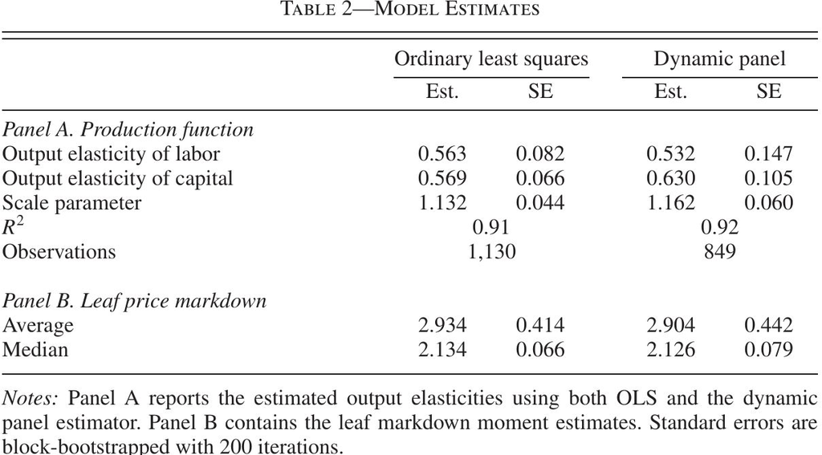

- BB double-differences out the confounds as it poses weaker assumptions on the correlation between unobservables and covariates ${\begingroup\Large\varepsilon\endgroup}[\xi_{it}-\xi_{it-1}+(\epsilon_{it}-\rho\epsilon_{it-1})-(\epsilon_{it}-\rho\epsilon_{it-1})|k_{it-1}, l_{it-1}]=0$ (see 2.3.1 of Ackerberg 2023). This eliminates the need to invert a demand to net out $\epsilon_{it}$, or of the scalar unobservable ass.
- By not inverting $\omega$, BB cannot separately identify $\omega+\epsilon$.
- BB estimates tend to be noisier due to weaker statistical power. See Table 2 from Rubens (2023).

  Rubens, Michael. 2023. “Market Structure, Oligopsony Power, and Productivity.” *American Economic Review* 113 (9): 2382–2410. https://doi.org/10.1257/aer.20210383.
- Weaker statistical power leads to the use of additional moment conditions (“system GMM” estimator).

  But the economic validity of additional moment conditions can be ambiguous.
- BB’s double-differencing eliminates the firm fixed effects $\alpha_{i}$ while DLW assumes $\alpha_{i}=0$.
- BB assumes AR(1) in $\omega_{it}$, not polynomials (as under first-order Markov).

# YMH method on markdown

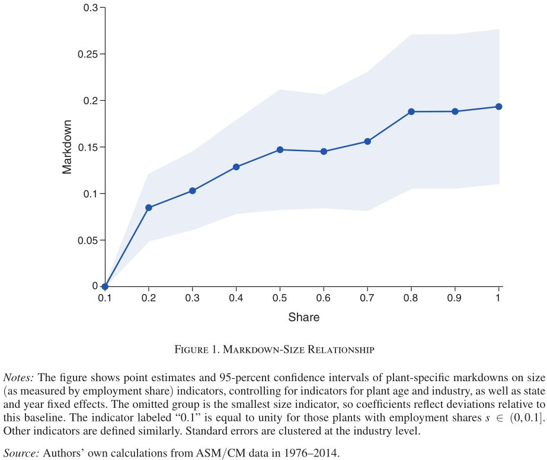

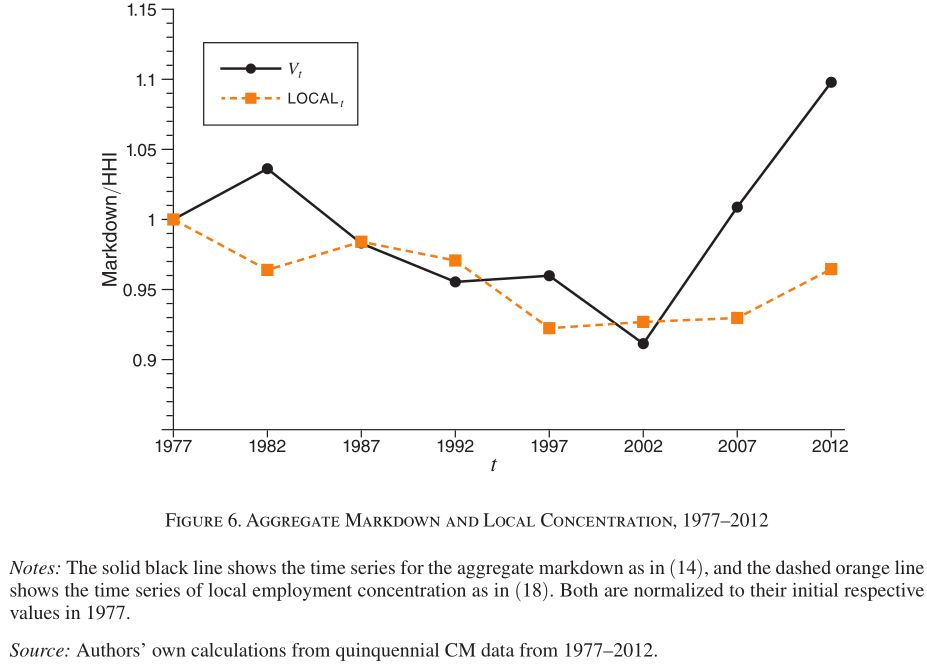

Yeh, Macaluso, and Hershbein (2022) showed markdown can be estimated with a formula similar to DLW.

Profit maximization (with a single input)
$$\max_{L}\;\;\; R(L)-w(L)L$$
FOC
$$R'(L)=w'(L)L+w(L)=\left(\frac{w'(L)L}{w(L)}+1\right)w(L)=\left(\varepsilon^{-1}_{s}+1\right)w(L)$$
where $\varepsilon^{-1}_{s}$ is an inverse elasticity of input $L$ supply (or input price elasticity of input supply function). This gives the markdown $\psi^{L}$:
$$\psi^{L}\equiv\frac{R'(L)}{w(L)}=\varepsilon^{-1}_{s}+1.$$
(Variable) Cost minimization (with a single input)
$$\mathcal L=w(L)L+\lambda[Q^{*}-F(L; \mathbf{V}, \omega)].$$
FOC
$$w'(L)L+w(L)=\lambda F_{L} \quad \Leftrightarrow \quad \underbrace{\frac{w'(L)L}{w(L)}+1}_{=\varepsilon^{-1}_{s}+1}=\frac{\lambda F_{L}}{w(L)}.$$
Then
$$\psi^{L}=\varepsilon^{-1}_{s}+1=\frac{\lambda}{P}\frac{F_{L}L}{Y}\frac{PY}{w(L)L}=\mu^{-1}\frac{\theta^{L}}{S^{L}}.$$
Or, with any other flexible input $V=K, M$ and markup $\mu^{V}$ derived from $V$, input price markdown for $L$ is given by:
$$\psi^{L}=\frac{\left(\frac{\theta^{L}}{S^{L}}\right)}{\left(\frac{\theta^{V}}{S^{V}}\right)}.$$
For implementation, Yeh et al. (2022) use the DLW algorithm.

How much more revenue is generated with an additional input cost. $>1$ under monopsony/oligoposny.

This formula has an extra benefit that it cancels out bias terms of using deflated revenues in place of quantity. See Proposition 2 of Appendix.

### Data

**Census of Manufactures**

Establishment level data of all manufactures in 1976-2014, collected in years ending with 2 and 7.  
Revenues and inputs (capital, labor, materials, energy) in monetary units.

*Census Bureau*

**NBER-CES Manufacturing Database**

Annual industry-level data from 1958-2018 on output, employment, payroll and other input costs, investment, capital stocks, TFP, and various industry-specific price indexes.

*National Bureau of Economic Research*

**Annual Survey of Manufactures**

Establishment level data of all manufactures in 1976-2014, rotating panel collected in every year.  
Large plants are sampled with near certainty, small plants are sampled less frequently.

*Census Bureau*

# Rubens’ method on markup and markdown

## Nonsubstitutability of materials

Production with Leontief in (raw) materials (tobacco leaves)
$$Q^{*}\leqslant \min\left\{\beta^{M}M, H(L, K)e^{\omega}\right\}$$
$M$ is more like a constraint that firm has to keep up with when changing other inputs… Cost minimization of planned production (free of $\epsilon$):
$$\mathcal L=W^{M}(M)M+W^{L}(L)L+\lambda\left[Q^{*}- \min\left\{\beta^{M}M, H(L, K)e^{\omega}\right\}\right].$$
FOC
$$W^{M'}(M)M\frac{dM}{dL}+W^{M}(M)\frac{dM}{dL}
+W^{L'}(L)L+W^{L}(L)=\lambda H_{L}e^{\omega}.$$
Rewriting
$$\underbrace{\left[\frac{W^{M'}(M)}{W^{M}}M+1\right]}_{\equiv\psi^{M}}W^{M}\frac{dM}{dL}+
\underbrace{\left[\frac{W^{L'}(L)}{W^{L}}L+1\right]}_{\equiv\psi^{L}}W^{L}
=
\lambda\underbrace{H_{L}e^{\omega}}_{\frac{\partial Q^{*}}{\partial L}}$$
$\psi^{M}$ is inverse material supply elasticity + 1 and $\psi^{L}$ is inverse labor supply elasticity + 1. So
$$\psi^{M}W^{M}\frac{\frac{dM}{dL}}{\frac{\partial Q^{*}}{\partial L}}
+\psi^{L}W^{L}\frac{1}{\frac{\partial Q^{*}}{\partial L}}=\lambda.$$
In Leontief, any increase in $M$ increases $Q^{*}$ at the same rate, or at $\frac{Q^{*}}{M}$:
$$\frac{\partial Q^{*}}{\partial L}\frac{dL}{dM}=\frac{Q^{*}}{M}=\frac{Ye^{-\epsilon}}{M}.$$
This gives
$$\psi^{M}W^{M}\frac{1}{\frac{Ye^{-\epsilon}}{M}}
+\psi^{L}W^{L}\frac{1}{\frac{\partial Ye^{-\epsilon}}{\partial L}}=\lambda.$$
Usual substitution gives
$$\begin{aligned}
\lambda
&=
P\psi^{M}\frac{W^{M}M}{PYe^{-\epsilon}}+
P\psi^{L}\frac{W^{L}L}{PY}\frac{1}{\frac{\partial Ye^{-\epsilon}}{\partial L}}\frac{1}{\frac{L}{Y}},\\
&=
P\psi^{M}S^{M}e^{\epsilon}+
P\psi^{L}S^{L}\frac{1}{\theta^{L}}e^{\epsilon},
\end{aligned}$$
or
$$\begin{equation}
\mu=\left[S^{M}\psi^{M}+
S^{L}\psi^{L}\frac{1}{\theta^{L}}\right]^{-1}e^{-\epsilon}.
\tag{4a}\label{4a}
\end{equation}$$

$\epsilon$ is missing, but it will not be a problem, because, in the end the paper does not invert a factor demand. But for comparability, I add it in below. To be exact with the paper, assume $\epsilon=0$.

DLW also consider Leontief in materials to which they call the “value added production function” as opposed to “gross output production function” in which they treat materials as substitutable. However, even with VA production function, they subtract the materials as if it is a preprocess of cost minimization and do not consider how materials affect FOCs.

$\eqref{4a}$ nests DLW (substitutable $S^{M}=0$ and input market competition $\psi^{V}=1$), Morlacco (2017, substitutable $S^{M}=0$ and input market non-competition $\psi^{V}>1$), and De Loecker and Scott (2022, nonsubstitutable $S^{M}>0$ and input market competition $\psi^{V}=1$) as special cases.

Note: There is $\color{red}{\text{no input demand inversion}}$ involved up to here.

- To be concrete, DLW’s formula does not necessarily imply its implementation (algorithm with inversion). Neither does YMH’s or Rubens’.

But we need to deal with $\epsilon$.

## Identification strategy “choices”

### Design choice

Yeh et al. (2022) estimated markups and markdowns simultaneously.

Rubens (2023) showed this is no longer possible (without further assumptions) once material is nonsubstitutable.

- 1 equation, 6 variables
- 3 unknowns: $\mu, \psi^{L}, \psi^{M}$
- 3 knowns (1 estimable: $\theta^{L}$, 2 observables: $S^{L}, S^{M}$)

Need to come up with a structure that gives values to 2 unknowns.

- $\psi^{L}=1$, $\mu_{i}=\mu=1$ and exogenously set by wholesalers, estimate $\psi^{M}$ (main text).
  - Other values of $\mu$ in Appendix.
- $\psi^{L}=1$, $\psi^{M}$ is given by a nested logit (over farmer occupations) framework (with many accompanying assumptions) as a function of estimated parameters of occupation share equation, estimate $\mu$ (Appendix A, C.1).
  - Noisy estimates.
- Others are possible.

Why are $\psi^{L}=1$, $\mu_{i}=\mu$ plausible?

- Wage rates did not change before and after consolidation.
- Wholesaler (state monopoly) unilaterally sets $P$.

Once we assume uniform exogenous markup and $\psi^{L}=1$, we have:
$$\begin{equation}
\begin{aligned}
\mu
&=
\frac{\beta^{L}}{S^{L}_{it}+\beta^{L}S^{M}_{it}\psi^{M}_{it}}, \\
(S^{L}_{it}+\beta^{L}S^{M}_{it}\psi^{M}_{it})\mu
&=
\beta^{L},\\
\psi^{M}_{it}
&=
\frac{\beta^{L}-\mu S^{L}_{it}}{\mu\beta^{L}S^{M}_{it}},\\
&=
\frac{1}{S^{M}_{it}}\left(\frac{1}{\mu}-\frac{S^{L}_{it}}{\beta^{L}}\right).
\end{aligned}
\tag{8}
\end{equation}$$

### Moment condition choice

How do we deal with $\epsilon$?

Proxy variable approach eliminates $\epsilon$ in the moment condition by inverting a factor demand to substitute for $\omega$.

Dynamic panel estimator leaves $\epsilon$ in the moment condition.

Rubens chooses the latter (proxy variable approach is in Appendix), because:

- Input demand (and its inversion) must control for (markups and) markdowns. This requires an additional structure or additional restrictions on their distributions. This limits the data from expressing heterogenous markups/markdowns.
- With additional parametric restrictions on productivity dynamics in dynamic panel estimator, heterogenous markdowns are obtained. Since markdown estimation is the main objective, this is better suited to the purpose.

  I do not fully understand this argument.

## Estimation steps

Main results set $\epsilon=0$ and use dynamic panel estimator.

Robustness check results invert a factor demand to purge $\epsilon$.

One could have retained $\epsilon$ and estimated dynamic panel, too.

### Estimation without $\epsilon$

1. Assume a production function with quality-unadjusted inputs $\tilde{l}, \tilde{k}$ and quality-unadjusted revenue with a quality adjustment function $a\left(p, w^{L}\right)$:
   $$q=\delta\left(\tilde{l}, \tilde{k}, \boldsymbol{\beta}\right)+a\left(p, w^{L}\right)+\omega$$
2. Incorporate a consolidation dummy in productivity dynamics and assume AR(1) in redisdual productivity:
   $$\omega_{it}=\boldsymbol{\beta}^{z'}\mathbf{z}_{it}+\tilde{\omega}_{it}, \quad \tilde{\omega}_{it}=\rho\tilde{\omega}_{it-1}+\nu_{it}$$
3. By $\rho$-differencing, form moment conditions ${\begingroup\Large\varepsilon\endgroup}[\hat{\nu}_{it}(\tilde{l}_{it-1}, \tilde{k}_{it}, \tilde{k}_{it-1})]=0,$ etc. and estimate $\boldsymbol{\beta}$.

### Estimation with $\epsilon$

Appendix C.1. deals with $\epsilon\neq 0$. It assumes leaf as flexible but nonsubstitutable inputs and inverts its demand (termed as “control function approach”).

Control function approach, proxy variable approach, production approach…all of them seem to refer to the same thing.

- The “CF Approach” uses Leontief: leaf price per case = leaf costs/output in cases. Use leaf price per case $w^{M}$ in the leaf demand inversion to control for differences in input price (input quality).
- Input demand is given by $m(p, w^{L}, w^{M}, \tilde{\mathbf{x}}, \boldsymbol{\beta}, \mu, \psi^{M}, \omega)$ in Appendix E and substitute $\mu=\mu(p, \gamma^{P}, \mathbf{s})$ with $\mathbf{s}$ is a vector of various market shares and $\gamma^{P}$ is price elasticity of output demand. $\gamma^{P}$ is assumed to be unique and to be subsumed in the intercept term (a strong ass.). $\psi^{M}$ is derived as $\psi^{M}(w^{M}, \mathbf{s})$. Everything is sort of first-order Taylor approximation.
  $$\begin{aligned}
  q
  &=
  \delta\left(\tilde{\mathbf{x}}, \boldsymbol{\beta}\right)+a\left(p, w^{L}\right)+\omega+\epsilon,\\
  &=
  \delta\left(\tilde{\mathbf{x}}, \boldsymbol{\beta}\right)+a\left(p, w^{L}\right)+h\left(p, w^{L}, w^{M}, \tilde{\mathbf{x}}, \boldsymbol{\beta}, \gamma^{P}, \mathbf{s}\right)+\epsilon,\\
  &=
  \phi\left(\tilde{\mathbf{x}}, \boldsymbol{\beta}, p, w^{L}, w^{M}, \mathbf{s}\right)+\epsilon.
  \end{aligned}$$

  Just derive $Q^{*}(\cdot)$ from cost minimzation FOCs and form $\frac{Q^{*}}{\beta^{M}}$ where $\beta^{M}$ is the quantity per case.
- Productivity is backed out with the use of quality adjustment function:
  $$\omega=\hat{\phi}-\delta\left(\tilde{\mathbf{x}}, \boldsymbol{\beta}\right)-a\left(p, w^{L}\right).$$
- Results do not change much (Table A4).

> “(T)he production approach to markup measurement does not hinge on a particular approach to estimate the production function. Rather it is an approach that delivers markups (and potentially marginal costs) for each individual producer (and time period), by exploiting standard cost minimization of a variable input in production.”

# GNR criticism and the proposed solution

Gandhi, Navarro, and Rivers (2020) showed that, for gross production functions, parameters are not indentified when using profit maximization FOC in material demand inversion and using IVs to estimate other parameters.

Gandhi, Amit, Salvador Navarro, and David A. Rivers. 2020. “On the Identification of Gross Output Production Functions.” *Journal of Political Economy* 128 (8): 2973–3016. https://doi.org/10.1086/707736.

There are three points in relationship with DLW:

1. GNR criticism is on gross production function estimation.
   - A *gross production function* describes production technology with material inputs.
   - A *value added production function* describes production technology only with non-materials, i.e., labour, and various forms of capital.
2. DLW formula and implementation (obtaining production function parameters) are separate objects. DLW formula is unrelated to GNR criticism.
3. DLW implementation is built on cost minimization FOC. GNR criticism is built on price-taking profit maximization FOC. We know that price-taking profit maximization FOCs and cost minimization FOCs share the same factor demand functions.
   - A profit maximization problem can be formulated as revenue minus a conditional cost function (conditional on output) which asks to find the optimal output volume.
   - A cost minimization problem does not consider the output market.
   - When the output market is competitive, the firm takes the price as given, and factor demand functions of two problems must coincide.

Is this a fatal blow to the “production approach”?

A monopsonist cost minimization problem
$$\min_{V} \;\;\; P^{V}V+\lambda[Q^{*}-F(K, L, M)e^{\omega}{\begingroup\Large\varepsilon\endgroup}[e^{\epsilon}]]$$
FOC
$$P^{V}+P^{V'}V-\lambda F_{V}e^{\omega}=0.$$
This gives
$$\begin{aligned}
\underbrace{\left(1+P^{V'}\frac{V}{P^{V}}\right)}_{\equiv \psi^{V}}P^{V}
&=\lambda F_{V}e^{\omega},\\
\psi^{V}\frac{P^{V}V}{PFe^{\omega}}
&=
\frac{\lambda}{P}F_{V}\frac{V}{Fe^{\omega}}e^{\omega},\\
\psi^{V}S^{V}
&=
\frac{1}{\mu}\theta^{V}e^{\omega},
\end{aligned}$$
$$\begin{equation}
\psi^{V|min}
=
\frac{e^{\omega}}{\mu}\frac{\theta^{V}}{S^{V}}.
\label{costpsi}
\end{equation}$$

A profit maximization problem
$$\max_{V} \;\;\; PF(K, L, M)e^{\omega}{\begingroup\Large\varepsilon\endgroup}[e^{\epsilon}]-P^{V}V$$
FOC
$$PF_{V}e^{\omega}+P'Fe^{\omega}\frac{dQ}{dV}-P^{V}-P^{V'}V=0.$$
This gives, noting $\frac{dQ}{dV}=F_{V}e^{\omega}$,
$$\begin{aligned}
\psi^{V}P^{V}
&=
PF_{V}e^{\omega}+P'Fe^{\omega}F_{V}e^{\omega},\\
&=
PF_{V}\left(e^{\omega}+\frac{\partial P}{\partial Q}\frac{Fe^{\omega}}{P}e^{\omega}\right),\\
\psi^{V}\frac{P^{V}V}{PFe^{\omega}}
&=
F_{V}\frac{V}{Fe^{\omega}}\left(1-\eta^{-1}\right)e^{\omega},\\
\psi^{V}S^{V}
&=
\theta^{V}\left(1-\eta^{-1}\right)e^{\omega},
\end{aligned}$$
$$\begin{equation}
\psi^{V|max}
=
(1-\eta^{-1})e^{\omega}\frac{\theta^{V}}{S^{V}}.
\label{profitpsi}
\end{equation}$$

A monopolist-monopsonist profit maximization problem can be written as an optimal production scale problem with a cost function $C(\cdot)$:
$$\max_{Q} \;\;\; PQe^{\omega}{\begingroup\Large\varepsilon\endgroup}[e^{\epsilon}]-C(Qe^{\omega})$$
FOC
$$\begin{aligned}
Pe^{\omega}+P'Qe^{\omega}-C'(Q)e^{\omega}
&=0,\\
C'(Q)
&=P\left(1+\frac{\partial P}{\partial \left(Qe^{\omega}\right)}\frac{Qe^{\omega}}{P}\right),\\
\frac{1}{\mu}
=\frac{C'(Q)}{P}&=1-\eta^{-1}.
\end{aligned}$$
Plugging this into $\eqref{costpsi}$, we have $\eqref{profitpsi}$:
$$\left.\psi^{V|min}\right|_{\mu^{-1}=1-\eta^{-1}}=\left(1-\eta^{-1}\right)e^{\omega}\frac{\theta^{V}}{S^{V}}=\psi^{V|max} .$$
We also note that $\psi^{V|min}$ or $\psi^{V|max}$ is equal to factor input price markdown. This is seen by solving the profit maximization problem formulated as:
$$\max_{V} \;\;\; R(V){\begingroup\Large\varepsilon\endgroup}[e^{\epsilon}]-P^{V}V$$
with FOC
$$R'(V)-P^{V'}V-P^{V}=0,$$
so
$$\mathrm{markdown}\equiv\frac{R'(V)}{P^{V}}=1+\frac{\partial P^{V}}{\partial V}\frac{V}{P^{V}}>1,$$
where $\frac{\partial P^{V}}{\partial V}\frac{V}{P^{V}}$ is an inverse factor supply elasticicty (or a price elasticity of factor supply) which is assumed to be upwardly sloped.

Given that cost minimization problem does not consider the output price $P$, the appearance of $\mu=\frac{P}{\lambda}$ is superfluous and is a clever accident. So $\eqref{costpsi}$ should read as, given markup $\mu$, markdown $\psi^{V}$ is determined such that $\eqref{costpsi}$ holds.

In contrast, profit maximization takes the output prices explicitly. So $\eqref{profitpsi}$ reads as, given the demand elasticity of output price $\eta$, markdown $\psi^{V}$ is determined such that $\eqref{profitpsi}$ holds.

This suggests that there is no reason to expect $\psi^{V|min}$ to be the same as $\psi^{V|max}$ given that only the latter specifies what sort of output price optimization is conducted. This is also seen that only after an explicit output price optimization $\psi^{V|min}$ changes to $\psi^{V|max}$.

We also note the markup of monopolist-monopsonist is given by
$$\mu=\frac{\eta}{\eta-1}>1.$$

## Criticism: Nonidentification of elasticity

In the absence of time-series variations in relative prices $\frac{P_{t}}{P^{V}_{t}}$, IV estimation (GMM) using lagged flexible inputs as instruments for current flexible inputs does not give unique values for output elasticity $\theta^{K}, \theta^{L}$ on $k, l$.

Even with time-series variations in relative prices, IV estimates suffer from weak identification. This is also shown in Monte Carlo by Kasahara and Sugita (2023).

## Why

$$\begin{aligned}
y_{it}
&=
f^{0}\left(\mathbf{x}_{it}\right)+\omega_{it}+\epsilon_{it},\\
&=
f^{0}\left(\mathbf{x}_{it}\right)-f^{0}_{M}\left(\mathbf{x}_{it}\right)-{\begingroup\Large\varepsilon\endgroup}[\epsilon_{it}]+d_{t}+\epsilon_{it}.
\end{aligned}$$
where we used price-taking expected profit maximization FOC
$$\max_{M_{it}}
\;\;\; {\begingroup\Large\varepsilon\endgroup}\left[P_{it}F^{0}(K_{it}, L_{it}, M_{it})e^{\omega_{it}+\epsilon_{it}}\right]-\rho_{it}M_{it}$$
$$\frac{\partial F^{0}\left(\mathbf{x}_{it}\right)e^{\omega_{it}}{\begingroup\Large\varepsilon\endgroup}[e^{\epsilon_{it}}]}{\partial M_{it}}=\frac{\rho_{it}}{P_{it}}.$$

$$f^{0}_{M}\left(\mathbf{x}_{it}\right)+\omega_{it}+{\begingroup\Large\varepsilon\endgroup}[\epsilon_{it}]=\underbrace{\ln\rho_{t}-p_{t}}_{\equiv d_{t}},
\quad
f^{0}_{M}\left(\mathbf{x}_{it}\right)=\ln\frac{\partial F^{0}\left(\mathbf{x}_{it}\right)}{\partial M_{it}},$$
so one can invert
$$\begin{aligned}
\omega_{it}
&=
\underbrace{-f^{0}_{M}\left(\mathbf{x}_{it}\right)-{\begingroup\Large\varepsilon\endgroup}[\epsilon_{jt}]}_{\equiv M^{-1}\left(\mathbf{x}_{it}\right)}+d_{t},\\
y_{it}
&=
f^{0}\left(\mathbf{x}_{it}\right)+\omega_{it}+\epsilon_{it},\\
&=
\underbrace{f^{0}\left(\mathbf{x}_{it}\right)+M^{-1}\left(\mathbf{x}_{it}\right)}_{\equiv \phi_{G}\left(\mathbf{x}_{it}\right)}+d_{t}+\epsilon_{it}.\quad (\phi_{G}+d_{t}=\phi \ \mathrm{of\ DLW})
\end{aligned}$$
Using $\phi_{G}$
$$\begin{aligned}
\omega_{it}
&=
f^{0}\left(\mathbf{x}_{it}\right)+M^{-1}\left(\mathbf{x}_{it}\right)+d_{t}-f^{0}\left(\mathbf{x}_{it}\right),\\
&=
\phi_{G}\left(\mathbf{x}_{it}\right)+d_{t}-f^{0}\left(\mathbf{x}_{it}\right),\\
\omega_{it-1}
&=
\phi_{G}\left(\mathbf{x}_{it-1}\right)+d_{t-1}-f^{0}\left(\mathbf{x}_{it-1}\right).
\end{aligned}$$
First-order Markov ass. gives
$$\begin{aligned}
\omega_{it}
&=
h^{0}\left(\omega_{it-1}\right)+\xi_{it}, \quad (h^{0}=g \ \mathrm{of\ DLW})\\
&=
h^{0}\left\{\phi_{G}\left(\mathbf{x}_{it-1}\right)+d_{t-1}-f^{0}\left(\mathbf{x}_{it-1}\right)\right\}+\xi_{it}.
\end{aligned}$$
So, with price-taking profit max FOC and FO Markov, we get
$$y_{it}=f^{0}\left(\mathbf{x}_{it}\right)+h^{0}\left\{\phi_{G}\left(\mathbf{x}_{it-1}\right)+d_{t-1}-f^{0}\left(\mathbf{x}_{it-1}\right)\right\}+\xi_{it}+\epsilon_{it}.$$

The statement: If $d_{t}=d$ for all $t$,

- Conditional expectation (conditioned on IVs $\Gamma_{it}$) of $y_{it}=f^{0}(\mathbf{x}_{it})+h^{0}(z)+\xi_{it}+\epsilon_{it}$ can be expressed as $E\left[f^{0}(\mathbf{x}_{it})\left|\right.\Gamma_{it}\right]+E\left[h^{0}(z)\left|\right.\Gamma_{it}\right]$.
- But, when we define new functions $\tilde{f}\neq f^{0}, \tilde{h}\neq h^{0}$ by mixing a nuisance function at a constant proportion $a$ for any $a\in(0, 1)$ as in the below, we can show (in Theorem 1) $E\left[f^{0}(\mathbf{x}_{it})\left|\right.\Gamma_{it}\right]+E\left[h^{0}(z)\left|\right.\Gamma_{it}\right]=E\left[\tilde{f}(\mathbf{x}_{it})\left|\right.\Gamma_{it}\right]+E\left[\tilde{h}(z)\left|\right.\Gamma_{it}\right]$.
- For true functions $f^{0}, h^{0}$, there are infinitely many *wrong* functions $\tilde{f}, \tilde{h}$, or different “parameters”, whose conditional expectations are identical (*observationally equivalent*). So conditional expectations of true functions cannot be identified uniquely by using IVs, or we say, functions $f^{0}, h^{0}$ are *not point identified*.

  When any two different model values $m_{1}, m_{2}\in\mathcal M$ are not observationally equivalent (i.e., parameters $\theta_{1}\neq\theta_{2}$ are different), the parameters $\theta$ of the model are said to be *point identified*. See Lewbel (2019).

  Lewbel, Arthur. 2019. “The Identification Zoo: Meanings of Identification in Econometrics.” *Journal of Economic Literature* 57 (4): 835–903. https://doi.org/10.1257/jel.20181361.

$$\begin{aligned}
\tilde{f}\left(\mathbf{x}_{it}\right)&\equiv (1-a)f^{0}\left(\mathbf{x}_{it}\right)+a\phi_{G}\left(\mathbf{x}_{it}\right),\\
\tilde{h}\left(z\right)&\equiv ad+(1-a)h^{0}\left(\frac{z-ad}{1-a}\right).
\end{aligned}$$

- Note: When one regresses $y_{it}$ on $\Gamma_{it}$, (given the same “what can be known from data” $\phi_{G}$ in the terms of Lewbel 2019, which is usually the distributions of data under certain i.i.d. sampling) **the same data/distributions of data/model value $m$ map to different parameter values** $f^{0}_{v}\neq \tilde{f}_{v}=f^{0}_{v}+a\frac{\partial M^{-1}}{\partial v}$ for any $a\in(0, 1)$ if $\frac{\partial M^{-1}}{\partial v}\neq 0$. So (true) parameters are not point identified.

  Lewbel, Arthur. 2019. “The Identification Zoo: Meanings of Identification in Econometrics.” *Journal of Economic Literature* 57 (4): 835–903. https://doi.org/10.1257/jel.20181361.

## GNR solution: Use price-taking profit maximization FOC to pin down material demand

Their Theorem 2 and 3 show that using the *share regression* recovers all parameters of production function nonparametrically:
$$\begin{equation}
s_{it}=\ln D^{\epsilon}\left(\mathbf{x}_{it}\right)+u^{\epsilon}_{it}.
\tag{s}
\label{sharereg}
\end{equation}$$

### Algorithm (in theory)

1. Estimate share regression: log shares on $\mathbf{x}_{it}$.
2. Get $\hat{\epsilon}_{it}=-\left(s_{it}-\ln \hat{D}^{\epsilon}\left(\mathbf{x}_{it}\right)\right)$ and $\hat{{\begingroup\Large\varepsilon\endgroup}}$ by the mean of $e^{\hat{\epsilon}_{it}}$, $\hat{f}_{m}=\frac{\hat{D}^{\epsilon}\left(\mathbf{x}_{it}\right)}{\hat{{\begingroup\Large\varepsilon\endgroup}}}$.
3. Integrate $\grave{f}=\int \hat{f}_{m}dm_{it}$ and compute $\hat{\mathcal Y}_{it}=y_{it}-\grave{f}-\hat{\epsilon}_{it}$.
4. Regress $\hat{\mathcal Y}_{it}$ on $k_{it}, l_{it}, k_{it-1}, l_{it-1}, \mathcal Y_{it-1}$, possible interactions of these and recover derivatives $\mathcal C_{v}$ of $v=k_{it}, l_{it}$.
5. Integrate $\int \hat{\mathcal C}_{v}dv=\hat{\mathcal C}+c$ which gives $\hat{\mathcal C}$ up to a constant.
6. Compute $\hat{f}\left(\mathbf{x}_{it}\right)+c=\grave{f}\left(\mathbf{x}_{it}\right)-\hat{\mathcal C}$, $\hat{\omega}_{it}+c=y_{it}-\grave{f}\left(\mathbf{x}_{it}\right)-\hat{\epsilon}_{it}$.

### Deriving the share regression

Price-taking profit maximization gives
$$P_{t}\frac{\partial F^{0}\left(\mathbf{x}_{it}\right)}{\partial M_{it}}e^{\omega_{it}}{\begingroup\Large\varepsilon\endgroup}[e^{\epsilon_{it}}]=\rho_{t}.$$
Noting
$$\frac{\partial \ln F^{0}\left(\mathbf{x}_{it}\right)}{\partial m_{it}}=
\frac{\partial \ln F^{0}\left(\mathbf{x}_{it}\right)}{\partial F^{0}}
\frac{\partial F^{0}}{\partial M_{it}}
\frac{\partial M_{it}}{\partial m_{it}}=\frac{1}{F^{0}}F^{0}_{M}M_{it},$$
where the last derivative is given by:
$$1=\frac{\partial M}{\partial M}=\frac{\partial M}{\partial m}\frac{\partial m}{\partial M}=\frac{\partial M}{\partial m}\frac{1}{M} \quad \Rightarrow \quad \frac{\partial M}{\partial m}=M,$$
so,
$$F^{0}_{M}=\frac{\partial \ln F^{0}\left(\mathbf{x}_{it}\right)}{\partial m_{it}}\frac{F^{0}}{M_{it}}=f^{0}_{m}\left(\mathbf{x}_{it}\right)\frac{F^{0}}{M_{it}}, \quad f^{0}_{m}\left(\mathbf{x}_{it}\right)\equiv\frac{\partial \ln F^{0}\left(\mathbf{x}_{it}\right)}{\partial m_{it}}.$$
Plugging this in gives:
$$\begin{aligned}
P_{t}f^{0}_{m}F^{0}\left(\mathbf{x}_{it}\right)e^{\omega_{it}}{\begingroup\Large\varepsilon\endgroup}[e^{\epsilon_{it}}]&=\rho_{t}M_{it},\\
P_{t}f^{0}_{m}\underbrace{F^{0}\left(\mathbf{x}_{it}\right)e^{\omega_{it}}e^{\epsilon_{it}}}_{\equiv Y_{it}}e^{-\epsilon_{it}}{\begingroup\Large\varepsilon\endgroup}[e^{\epsilon_{it}}]=\rho_{t}M_{it},\\
f^{0}_{m}e^{-\epsilon_{it}}{\begingroup\Large\varepsilon\endgroup}[e^{\epsilon_{it}}]=\frac{\rho_{t}M_{it}}{P_{it}Y_{it}}\equiv S_{it}.
\end{aligned}$$
Taking logs and denoting $\ln E[e^{\epsilon_{it}}]=\ln{\begingroup\Large\varepsilon\endgroup}$ gives $\eqref{sharereg}$:
$$s_{it}=\underbrace{\ln f^{0}_{m}+\ln\varepsilon}_{\equiv \ln D^{\epsilon}\left(\mathbf{x}_{it}\right)}-\epsilon_{it}, \quad D^{\epsilon}\left(\mathbf{x}_{it}\right)=f^{0}_{m}\left(\mathbf{x}_{it}\right){\begingroup\Large\varepsilon\endgroup}[e^{\epsilon_{it}}].$$

### Thereom 2 states that one can recover $\hat{f}_{m}$ by using a share regression:

Given $\omega_{it}, \mathbf{x}_{it}\in\mathcal I_{it}$ we have $E[\epsilon_{it}|\mathcal I_{it}]=0$, so regressing $s_{it}$ on a flexible function of $\mathbf{x}_{it}$ identifies $f^{0}_{m}$ as a set of coefficients on the part of $m_{it}$.
$$E\left.\left[s_{it}\right|\mathbf{x}_{it}\right]=\ln D^{\epsilon}\left(\mathbf{x}_{it}\right).$$
This identifies $D^{\epsilon}$. This gives $\epsilon_{it}$ and ${\begingroup\Large\varepsilon\endgroup}=E[e^{\epsilon_{it}}]$:
$$\hat{\epsilon}_{it}=\ln \hat{D}^{\epsilon}-s_{jt}, \quad \hat{{\begingroup\Large\varepsilon\endgroup}}=E\left[e^{\ln \hat{D}^{\epsilon}-s_{jt}}\right].$$
This gives:
$$\begin{aligned}
\ln \hat{f}_{m}
&=\ln \hat{D}^{\epsilon}-\ln\hat{{\begingroup\Large\varepsilon\endgroup}},\\
\hat{f}_{m}
&=\frac{\hat{D}^{\epsilon}}{\hat{{\begingroup\Large\varepsilon\endgroup}}}.
\end{aligned}$$

### Thereom 3 states that one can recover the rest of $f$ up to a constant if $\hat{f}_{m}$ is known:

By the fundamental theorem:
$$\begin{equation}
\int f^{0}_{m}\left(\mathbf{x}_{it}\right)dm_{it}=f^{0}\left(\mathbf{x}_{it}\right)+\mathcal C(k_{it}, l_{it}), \quad \mathrm{or}\quad
f^{0}\left(\mathbf{x}_{it}\right)=\int f^{0}_{m}\left(\mathbf{x}_{it}\right)dm_{it}-\mathcal C(k_{it}, l_{it}).
\tag{f}\label{f0identified}
\end{equation}$$
where the constant of integration $\mathcal C$ is allowed to depend on $k_{it}, l_{it}$, or $\mathcal C=c_{0}+c_{1}(k_{it}, l_{it})$ without loss of generality. So if we can compute $\mathcal C$, then we can identify all of $f^{0}\left(\mathbf{x}_{it}\right)$. GNR says we can identify $f^{0}\left(\mathbf{x}_{it}\right)$ up to a constant, so we can can still discuss partials $f_{v}$ and do analysis on productivity $\omega_{it}$ by taking a ratio to the most/least productive firm $i=0$ with $\hat{\omega}_{it}-\omega^{0t}$.

Start with the production function in logs:
$$\begin{aligned}
\omega_{it}
&=
y_{it}-f^{0}-\epsilon_{it},\\
&=
y_{it}-\left\{\int f^{0}_{m}\left(\mathbf{x}_{it}\right)dm_{it}-\mathcal C(k_{it}, l_{it})\right\}-\epsilon_{it}.
\end{aligned}$$
Define
$$\begin{aligned}
\mathcal Y_{it}
&\equiv
y_{it}-\int f^{0}_{m}\left(\mathbf{x}_{it}\right)dm_{it}-\epsilon_{it},\\
&=
\omega_{it}-\mathcal C(k_{it}, l_{it}).
\end{aligned}$$
Note that given we have $\hat{\epsilon}_{it}$ and $\hat{f}^{0}_{m}$, we can get $\hat{\mathcal Y}_{it}$. Using first-order Markov on $\omega_{it}$
$$\begin{aligned}
\mathcal Y_{it}
&=
h^{0}\left\{\omega_{it-1}\right\}+\xi_{it}-\mathcal C(k_{it}, l_{it}),\\
&=
h^{0}\left\{\mathcal Y_{it-1}+\mathcal C(k_{it-1}, l_{it-1})\right\}+\xi_{it}-\mathcal C(k_{it}, l_{it}).
\end{aligned}$$
Denote $\Gamma_{y}=(k_{it}, l_{it}, k_{it-1}, l_{it-1}, \mathcal Y_{it-1})$. Then
$$E\left.\left[\mathcal Y_{it}\right|\Gamma_{y}\right]=-\mathcal C(k_{it}, l_{it})+h^{0}\left\{\mathcal Y_{it-1}+\mathcal C(k_{it-1}, l_{it-1})\right\}.$$
Then we get the partial derivatives of $c_{1}(k_{it}, l_{it})$ of integration $\mathcal C$ as (negative) coefficients on $k_{it}, l_{it}$ conditional on $\mathcal Y_{it-1}k_{it-1}, l_{it-1}$. As we cannot identify $c_{0}$ part, the constant of integration $\mathcal C$ is identified up to a constant. Using this in $\eqref{f0identified}$ gives $\hat{f}^{0}$ up to a constant.

### Under monpoly, share regression does not give $f^{0}_{m}$

But, we are trying to estimate markdowns and markups. Why a price taker?

- “Share regression” cannot be derived for imperfectly competitive output market.

Monopolist profit maximization gives
$$\begin{aligned}
\rho_{t}
&=
\left(P'_{t}F^{0}\left(\mathbf{x}_{it}\right)+P_{t}\frac{\partial F^{0}\left(\mathbf{x}_{it}\right)}{\partial M_{it}}\right)e^{\omega_{it}}{\begingroup\Large\varepsilon\endgroup}[e^{\epsilon_{it}}],\\
&=
\left(\frac{\partial P}{\partial Y_{it}}\frac{F^{0}\left(\mathbf{x}_{it}\right)}{P_{t}}+f^{0}_{m}\left(\mathbf{x}_{it}\right)\frac{F^{0}}{M_{it}}\right)P_{t}e^{\omega_{it}}{\begingroup\Large\varepsilon\endgroup}[e^{\epsilon_{it}}],\\
&=
\left(-\eta^{-1}(\mathbf{x}_{it}, \omega_{it}, \epsilon_{it})+f^{0}_{m}\left(\mathbf{x}_{it}\right)\frac{F^{0}e^{\omega_{it}}{\begingroup\Large\varepsilon\endgroup}[e^{\epsilon_{it}}]}{M_{it}}\right)P_{t},\\
S_{it}
&=
-\eta^{-1}(\mathbf{x}_{it}, \omega_{it}, \epsilon_{it})\frac{M_{it}}{Y_{it}}+f^{0}_{m}\left(\mathbf{x}_{it}\right),\\
&=
-\frac{\eta^{-1}(\mathbf{x}_{it}, \omega_{it}, \epsilon_{it})}{\beta^{M}}+f^{0}_{m}\left(\mathbf{x}_{it}\right), \quad \beta^{M}\equiv\frac{M_{it}}{Y_{it}}.\\
\end{aligned}$$
$\mathbf{x}_{it}$ appears both in $\eta$ and $f^{0}_{m}$ and two cannot be separately identified.

## What shall we do?

- Some papers (e.g., Kasahara and Sugita 2023) are working on the solution.
- A parametric solution under a Cobb-Douglas production had been proposed (Doraszelski and Jaumandreu 2013).

  Doraszelski, Ulrich, and Jordi Jaumandreu. 2013. “R& D and productivity: Estimating endogenous productivity.” *The Review of Economic Studies* 80 (4): 1338–83. https://doi.org/10.1093/restud/rdt011.
- We can first do concentration, then proceed to Rubens’ or DJ’s method, and wait to see if any nonparametric (non-functional form dependent) alternative comes up.

# Empirical background

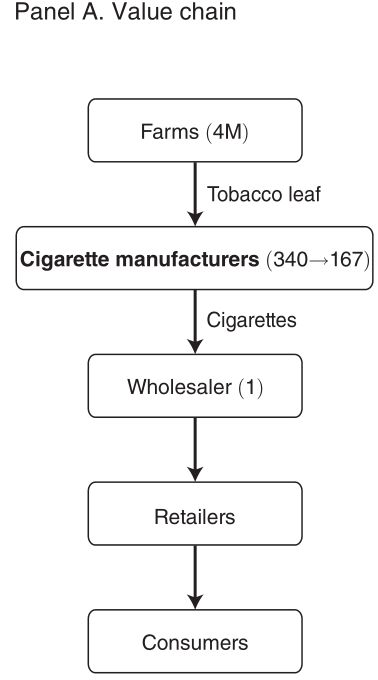

## Farmers

- 4 million tobacco farms in China (2003), mostly small scale around .3-.4 ha (FAO 2003).
- Planting is annual, not perennial.
- Farmers choose which purchasing stations or intermediaries (both under particular manufacturers) within county borders to sell the leaves.
- State Tobacco Monopoly Administration (STMA) annually sets leaf prices by quality grades, but manufacturers can flexibly change the effective prices through redefining grades and influencing local STMA management.
- Tobacco farming got less profitable by year, but switching costs and local polical pressures for tax base prevented farmer conversions. Farmers lose cultivation rights once they move to elsewhere, so they are more tied to the location.

## Cigarrete manufacturers

- Variable input costs consist of intermediate inputs (90%, of which 2/3 is tobacco leaves, 1/3 is paper) and labour (10%).
- Operate as separate enterprises although formally belong to Chinese National Tobacco Corporation (CNTC).
- Sell to a (monopsonistic) wholesaler controlled by Chinese National Tobacco Trade Corporation (CNTTC) and State STMA.
- Wholesaler unilaterally sets cigarette factory gate prices and sells across the country.
- Exports count 1% and imports count .2% of total industry revenue in 2019.

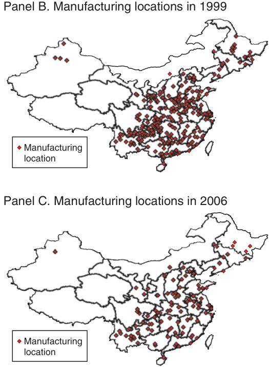

## Consolidation policy

May 2002, STMA ordered:

- Close down of all (98) SOEs producing less than 100K cigarette cases per year.

  3 noncomplier firms survived by 2006.
- Encouragement to 99 SOEs producing below 300K cases to be mergered with larger manufactures.

  51 noncomplier firms survived by 2006.
- Number of cigarette manufacturers: 340 (1999) $\rightarrow$ 167 (2006)

# Data

**Annual survey of industrial firms**

Establishment level data of all cigarette manufactures in 1999-2006, non-SOEs with sales greater than 5 million RMB and all SOEs, 470 firms with 2025 observations.  
Production and cost data in monetary units.  
Including 1132 observations of 257 firms that come with quantity information.

*National Bureau of Statistics*

**2000 Census of Population**

County level demographic information.

*Harvard Dataverse*

**Weather data**

County level weather

*Chinese Meteorological Agency*

**Brand information data**

Brand level cigarette characteristics

*O’Connor et al. (2010)*

**Product information data**

Product level characteristics. Quality grades, subsidy.

*National Bureau of Statistics*

**FAOSTAT**

Agricultural prices

*FAO*

**UN COMTRADE**

Aggregate trade flows

*UN*

# Results

## Cost shares

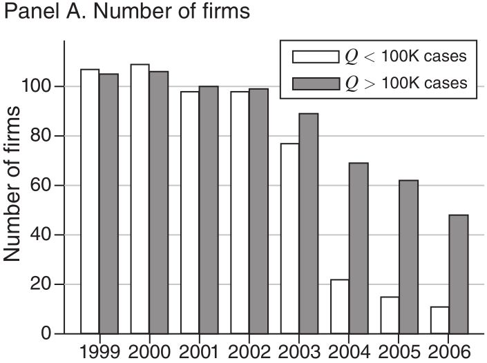

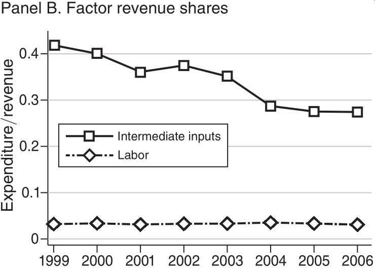

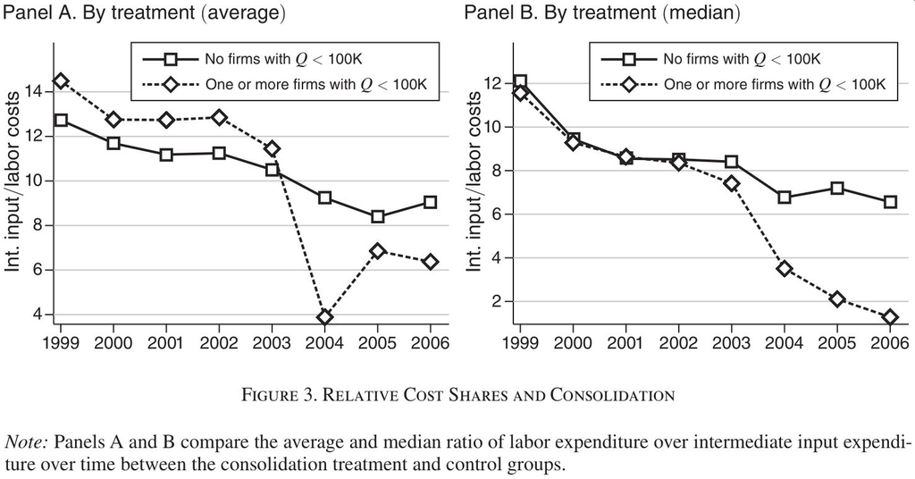

Cost share of the leaves decreased relative to labor among the treated (below 100K cases) relative to the controls (above 100K case firms).

## Markdowns and productivity

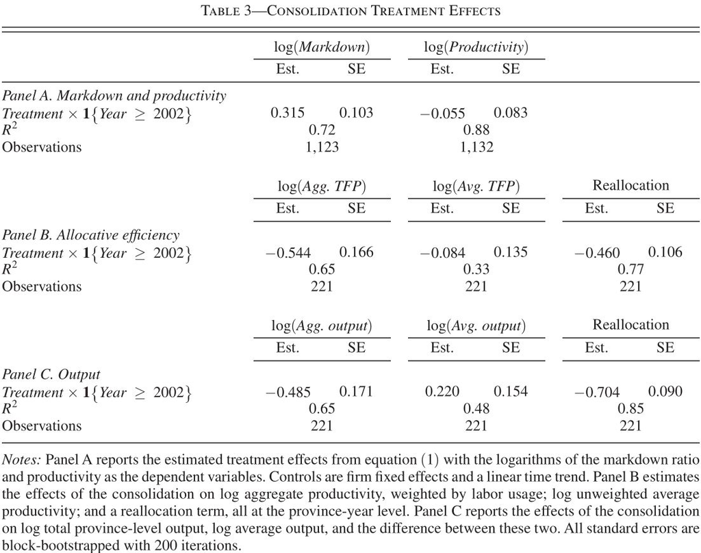

Markdown increased (37%).

Manufacturers reduced outputs (38%), thereby reducing leaf demand and prices.

Manufacturers’ provincial aggregate productivity decreased (42 %), mostly due to leaf (mis)reallocation to low productivity manufacturers (37 pp), less so to individual TFP growth slowdown.

Using number of workers as weights. Note the difference with the simple average.

When markdown is modeled and estimated as farmers’ buyer choices (Table A1, A2), markup becomes the estimate. Estimated markup is larger which indicates cigarette price manipulations by manufacturers (with nonmarket power on the wholesaler).

- Markup estimates are noisy.

  I think this choice could have been author’s first choice if the markups and markdowns are more precisely estimated.

Robustness checks

- Endogenous $\psi^{M}$ with farmer choice
- Endogenous firm exit
- Leaf substitutablity in production
- Labor augmeting tech
- Cost share approach
- Leaf market definition
- Leaf definition changes, only large firms, different markup calibration